# Introduction to Microsoft R Server

June 6, 2016

## Overview of Microsoft R Server

## Learning Plan

### What You'll Learn

- What is Microsoft R Server, and how it addresses R's limitations
- What's RevoScaleR external data frame data type that extends R's data structures to out-of-memory objects
- How to develop predictive models with Microsoft R Server
- How to test predictive models with Microsoft R Server

## Microsoft R Server

### REvolution

MRS extends open-source R to allow:

- Multi-threading
- Matrix operations, linear algebra, and many other math operations to run on all available cores
- Parallel Processing
- ScaleR functions utilize all available resources, local or distributed
- On-disk data storage
- RAM limitations lifted
- data store could be HDFS, SQL Server, Blob Storage, Teradata…

## Compute Contexts

### Move Your Compute

- You can adjust the compute context for Microsoft R Server
- All subsequent operations will operate in the new compute context, no need to rewrite code
- For local compute contexts, you can utilize all cores to optimize your math operations for parallel processes
- Your data is constrained by your disk space, not your RAM
- For distribute compute contexts, such as Hadoop, you can conduct parallel execution on all available nodes
- Utilize distributed file systems like HDFS to scale your data size

## How MRS Works

### Parallel External Memory Algorithms (PEMA)

1. Data is saved in a blockwise, chunked manner
2. A chunk/subset of data is extracted from the main dataset and brought into memory
3. An intermediate result is calculated from that chunk of data
4. Intermediate results are computed, reduced into final data

## Available Algorithms

- Linear regression (rxLinMod)
- Generalized linear models (rxLogit, rxGLM)
- Decision trees (rxDTree)
- Gradient boosted decision trees (rxBTree)
- Decision forests (rxDForest)
- K-means (rxKmeans)
- NaiÌˆve Bayes (rxNaiveBayes)
- More to come through the RML Package in Fall 2016

## Data Manipulation and Summarization with MRS

## Import Flights Data to XDF

```r
library(nycflights13)
flights_xdf <- rxImport(inData = flights, outFile = "../data/flights.xdf",
                        overwrite = TRUE)
rxGetInfo(flights_xdf, getVarInfo = TRUE)
```

```
## File name: C:\Users\alizaidi\OneDrive - Microsoft\R\MRS-for-trainers\data\flights.xdf
## Number of observations: 336776
## Number of variables: 19
## Number of blocks: 1
## Compression type: zlib
## Variable information:
## Var 1: year, Type: integer, Low/High: (2013, 2013)
## Var 2: month, Type: integer, Low/High: (1, 12)
## Var 3: day, Type: integer, Low/High: (1, 31)
## Var 4: dep_time, Type: integer, Low/High: (1, 2400)
## Var 5: sched_dep_time, Type: integer, Low/High: (106, 2359)
## Var 6: dep_delay, Type: numeric, Low/High: (-43.0000, 1301.0000)
## Var 7: arr_time, Type: integer, Low/High: (1, 2400)
## Var 8: sched_arr_time, Type: integer, Low/High: (1, 2359)
## Var 9: arr_delay, Type: numeric, Low/High: (-86.0000, 1272.0000)
## Var 10: carrier, Type: character
## Var 11: flight, Type: integer, Low/High: (1, 8500)
## Var 12: tailnum, Type: character
## Var 13: origin, Type: character
## Var 14: dest, Type: character
## Var 15: air_time, Type: numeric, Low/High: (20.0000, 695.0000)
## Var 16: distance, Type: numeric, Low/High: (17.0000, 4983.0000)
## Var 17: hour, Type: numeric, Low/High: (1.0000, 23.0000)
## Var 18: minute, Type: numeric, Low/High: (0.0000, 59.0000)
## Var 19: time_hour, Type: POSIXct, Low/High: (2013-01-01 05:00:00, 2013-12-31 23:00:00), Time Zone = UTC
```

## Summarizing XDFs

### rxSummary

- We can summarize columns of an XDF using the `rxSummary` function
- Summary statistics for numeric variables, and tabulations for factors

```r
rxSummary(~ ., data = flights_xdf)
```

```
## Call:
## rxSummary(formula = ~., data = flights_xdf)
##
## Summary Statistics Results for: ~.
## Data: flights_xdf (RxXdfData Data Source)
## File name: ../data/flights.xdf
## Number of valid observations: 336776
##
##  Name           Mean                StdDev       Min
##  year           2013                0.000000e+00 2013
##  month          6.54850998883537    3.414457e+00 1
##  day            15.7107869919471    8.768607e+00 1
##  dep_time       1349.10994730931    4.882818e+02 1
##  sched_dep_time 1344.25484001236    4.673358e+02 106
##  dep_delay      12.6390702573048    4.021006e+01 -43
##  arr_time       1502.05499858258    5.332641e+02 1
##  sched_arr_time 1536.38022008693    4.974571e+02 1
##  arr_delay      6.89537675731489    4.463329e+01 -86
##  flight         1971.92361985413    1.632472e+03 1
##  air_time       150.68646019808     9.368830e+01 20
##  distance       1039.9126036297     7.332330e+02 17
##  hour           13.1802474048032    4.661316e+00 1
##  minute         26.2300995320331    1.930085e+01 0
##  time_hour      2013-07-03 05:02:36 9.010074e+06 2013-01-01 05:00:00
##  Max                 ValidObs MissingObs
##  2013                336776      0
##  12                  336776      0
##  31                  336776      0
##  2400                328521   8255
##  2359                336776      0
##  1301                328521   8255
##  2400                328063   8713
##  2359                336776      0
##  1272                327346   9430
##  8500                336776      0
##  695                 327346   9430
##  4983                336776      0
##  23                  336776      0
##  59                  336776      0
##  2013-12-31 23:00:00 336776      0
```

## Creating Factors

### rxFactors

- We didn't specify factor variables inside of `rxImport`
- By default, `rxImport` assumes `stringsAsFactors = HELLNO`
- `rxFactors` can be used to convert character/numeric columns into factors

```r
rxFactors(inData = flights_xdf,
          outFile = flights_xdf,
          factorInfo = list(
              carrier_F = list(varName = "carrier"),
              origin_F = list(varName = "origin"),
              dest_F = list(varName = "dest")),
          overwrite = TRUE)
# rxSummary(~ ., data = flights_xdf)
```

## Summarizing Data in Groups

- You can summarize multiple columns at a time with `rxSummary`
- You can also summarize data in groups by indicating dependencies

```r
# rxSummary(~arr_delay + dep_delay, data = flight_xdf)
rxSummary(arr_delay ~ origin_F, data = flights_xdf)
```

```
## Call:
## rxSummary(formula = arr_delay ~ origin_F, data = flights_xdf)
##
## Summary Statistics Results for: arr_delay ~ origin_F
## Data: flights_xdf (RxXdfData Data Source)
## File name: ../data/flights.xdf
## Dependent variable(s): arr_delay
## Number of valid observations: 336776
##
##  Name               Mean     StdDev   Min Max  ValidObs MissingObs
##  arr_delay:origin_F 6.895377 44.63329 -86 1272 327346   9430
##
## Statistics by category (3 categories):
##
##  Category                   origin_F Means    StdDev   Min Max  ValidObs
##  arr_delay for origin_F=EWR EWR      9.107055 45.52918 -86 1109 117127
##  arr_delay for origin_F=LGA LGA      5.783488 43.86227 -68  915 101140
##  arr_delay for origin_F=JFK JFK      5.551481 44.27745 -79 1272 109079
```

## Approximate Quantiles

### rxQuantile

- To calculate approximate quantiles you can use the `rxQuantile` function

```r
rxQuantile(varName = "arr_delay", data = flights_xdf)
```

```
##   0%  25%  50%  75% 100%
##  -86  -17   -5   14 1272
```

```r
lapply(c("arr_delay", "dep_delay"), rxQuantile, data = flights_xdf)
```

```
## [[1]]
##   0%  25%  50%  75% 100%
##  -86  -17   -5   14 1272
##
## [[2]]
##   0%  25%  50%  75% 100%
##  -43   -5   -2   11 1301
```

## Cross Tabulations

### rxCrossTabs

- For categorical data, you can create contingency tables with `rxCrossTabs`

```r
rxCrossTabs( ~ origin_F : carrier_F, data = flights_xdf)
```

```
## Call:
## rxCrossTabs(formula = ~origin_F:carrier_F, data = flights_xdf)
##
## Cross Tabulation Results for: ~origin_F:carrier_F
## Data: flights_xdf (RxXdfData Data Source)
## File name: ../data/flights.xdf
## Number of valid observations: 336776
## Number of missing observations: 0
## Statistic: counts
##
## origin_F:carrier_F (counts):
##         carrier_F
## origin_F    UA    AA    B6    DL    EV    MQ    US   WN   VX   FL  AS
##      EWR 46087  3487  6557  4342 43939  2276  4405 6188 1566    0 714
##      LGA  8044 15459  6002 23067  8826 16928 13136 6087    0 3260   0
##      JFK  4534 13783 42076 20701  1408  7193  2995    0 3596    0   0
##         carrier_F
## origin_F    9E  F9  HA  YV OO
##      EWR  1268   0   0   0  6
##      LGA  2541 685   0 601 26
##      JFK 14651   0 342   0  0
```

```r
# rxCrossTabs( ~ origin_F : F(month), data = flights_xdf)
```

## Cross Tabulations

### rxCube

- You can calculate cross-tabulated sums and averages very efficiently with `rxCube`
- Does similar computations as `rxCrossTabs`, but different return format and generally more efficient

```r
rxCube(arr_delay ~ carrier_F : F(month), data = flights_xdf,
       means = TRUE)
```

```
## Call:
## rxCube(formula = arr_delay ~ carrier_F:F(month), data = flights_xdf,
##     means = TRUE)
##
## Cube Results for: arr_delay ~ carrier_F:F(month)
## File name: ../data/flights.xdf
## Dependent variable(s): arr_delay
## Number of valid observations: 327346
## Number of missing observations: 9430
## Statistic: arr_delay means
##
##     carrier_F F_month arr_delay    Counts
## 1   UA        1         3.17559913 4590
## 2   AA        1         0.98237885 2724
## 3   B6        1         4.71719918 4413
```

[output cut: 189 more lines]

```r
# rxCube(arr_delay ~ carrier_F : F(month), data = flights_xdf)
```

## Returning Dataframes with rxCube

- rxCube as an argument `returnDataFrame`

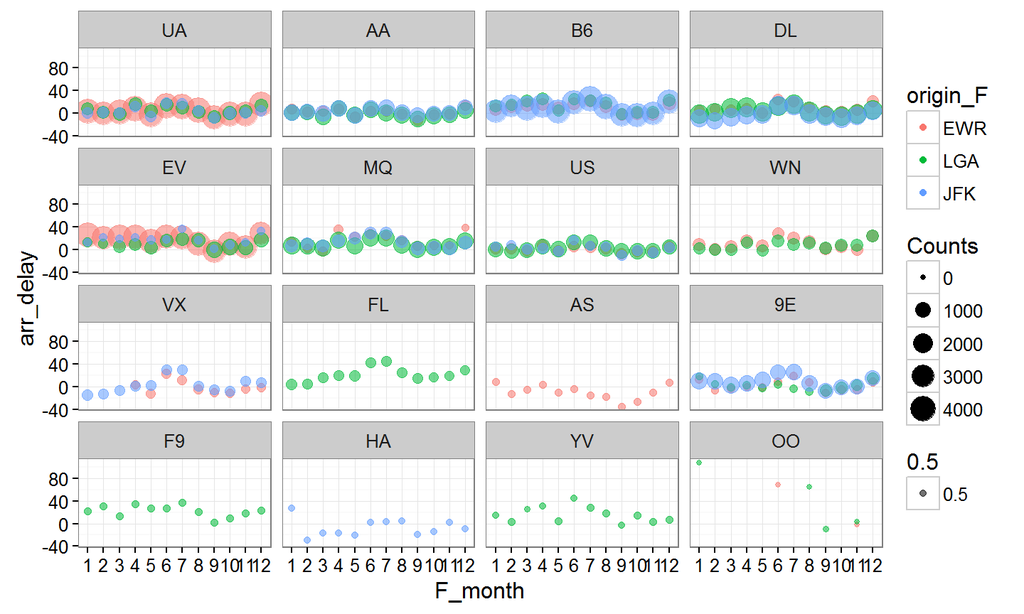

```r
library(ggplot2)
library(magrittr)
rxCube(arr_delay ~ carrier_F:F(month):origin_F, data = flights_xdf,
       means = TRUE, returnDataFrame = TRUE) %>%
  ggplot(aes(x = F_month, y = arr_delay)) +
  geom_point(aes(size = Counts, color = origin_F, alpha = 0.5)) +
  facet_wrap(~carrier_F) + theme_bw()
```

## Transformations

- It's very easy to do row-wise operations with `rxDataStep`

```r
rxDataStep(inData = flights_xdf,
           outFile = flights_xdf,
           transforms = list(date = as.Date(paste(year, month, day, sep = "-")),
                             dayOfWeek = format(date, format = "%A")),
           overwrite = TRUE)
```

## Convert Day of Week to Factor

```r
rxFactors(inData = flights_xdf,
          outFile = flights_xdf,
          factorInfo = list(
              dayOfWeek_F = list(varName = "dayOfWeek",
                                 levels = c("Sunday", "Monday", "Tuesday",
                                            "Wednesday", "Thursday", "Friday",
                                            "Saturday"))
          ),
          overwrite = TRUE
)
```

## Estimating Models

## Splitting Data into Training and Test Sets

- To compare different models, we can split the data into train and validation sets
- Let's try to estimate binary classification models for arrival delays

```r
rxDataStep(inData = flights_xdf,
           outFile = flights_xdf,
           transforms = list(was_delayed = factor(ifelse(arr_delay > 0,
                                                         1, 0),
                                                  levels = c("0", "1"))),
           overwrite = TRUE)
```

## Splitting Data into Training and Test Sets

```r
train_xdf <- rxDataStep(inData = flights_xdf,
                        outFile = "../data/train.xdf",
                        rowSelection = month <= 6,
                        overwrite = TRUE)

rxDataStep(inData = flights_xdf,
           outFile = "../data/test.xdf",
           rowSelection = month > 6,
           overwrite = TRUE) -> test_xdf
```

## Estimate Model

### Decision Tree

- We can estimate a variety of tree-based algorithms

```r
delay_prediction <- rxDTree(was_delayed ~ carrier_F +
                              date + dayOfWeek_F +
                              origin_F + dest_F,
                            method = "class", pruneCp = "auto",
                            data = train_xdf)
# plot(RevoTreeView::createTreeView(delay_prediction))
```

## Estimate Model

### Decision Forest

```r
delay_prediction_forest <- rxDForest(was_delayed ~ carrier_F +
                                     date + dayOfWeek_F +
                                     origin_F + dest_F,
                                   method = "class", nTree = 10,
                                   data = train_xdf)
```

## Estimate Model

### Gradient Boosted Trees

```r
delay_prediction_sgb <- rxBTrees(was_delayed ~ carrier_F +
                                   date + dayOfWeek_F +
                                   origin_F + dest_F,
                                   method = "class", nTree = 10,
                                   data = train_xdf)
```

## Test Models

### Decision Tree

- Now that we have our three trained models, we can score/test them
- The scoring function for the MRS PEMA algorithms is `rxPredict`

```r
rxPredict(delay_prediction,
          outData = "../data/predict.xdf",
          writeModelVars = TRUE,
          data = test_xdf,
          predVarNames = c("0_tree", "1_tree"),
          overwrite = TRUE) -> predict_xdf
```

## Test Models

### Decision Forest

- We will score the decision forest model on the same dataset
- Slightly different output, so we're going to use the additional parameters

```r
rxPredict(delay_prediction_forest,
          outData = "../data/predict.xdf",
          writeModelVars = TRUE,
          predVarNames = c("0_forest", "1_forest", "delay_pred_forest"),
          data = test_xdf, type = "prob") -> predict_xdf
```

## Test Models

### Boosted Trees

- And finally, the stochastic gradient boosted trees

```r
rxPredict(delay_prediction_sgb,
          outData = "../data/predict.xdf",
          writeModelVars = TRUE,
          predVarNames = c("1_sgb"),
          data = test_xdf, type = "prob") -> predict_xdf
```

## Model Comparison

- First let's convert the binary target class into an integer

```r
rxDataStep(inData = predict_xdf@file,
           outFile = predict_xdf,
           transforms = list(arrival_delay = as.integer(as.character(was_delayed))),
           overwrite = TRUE)
```

## Model Comparison

### ROC Curve

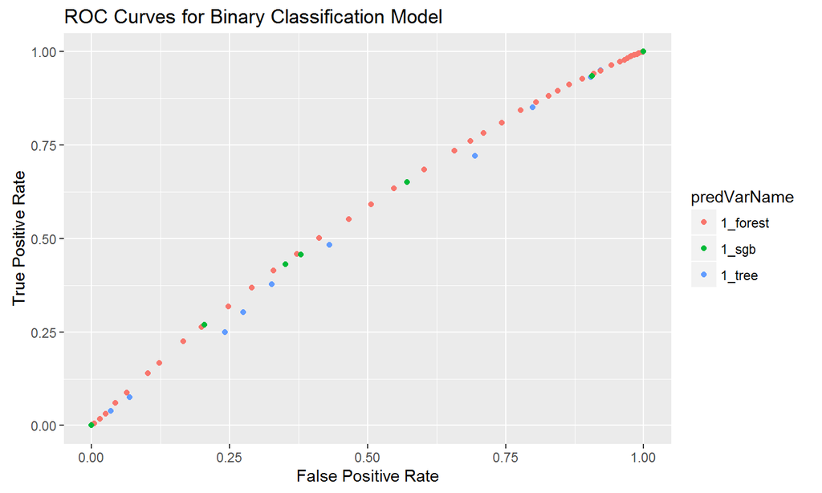

```r
roc_values <- rxRoc(actualVarName = "arrival_delay",
           predVarNames = c("1_tree", "1_forest", "1_sgb"),
           data = predict_xdf)
library(ggplot2)
ggplot(roc_values,
    aes(x = 1 - specificity, y = sensitivity, colour = predVarName)) +
    geom_point() + xlab("False Positive Rate") +
    ylab("True Positive Rate") +
    ggtitle("ROC Curves for Binary Classification Model")
```

```r
    theme_bw()
```

[output not shown]

[output cut: 245 more lines]

[output not shown]